# Seminario Hadley Wickham

# Análisis de los supuestos

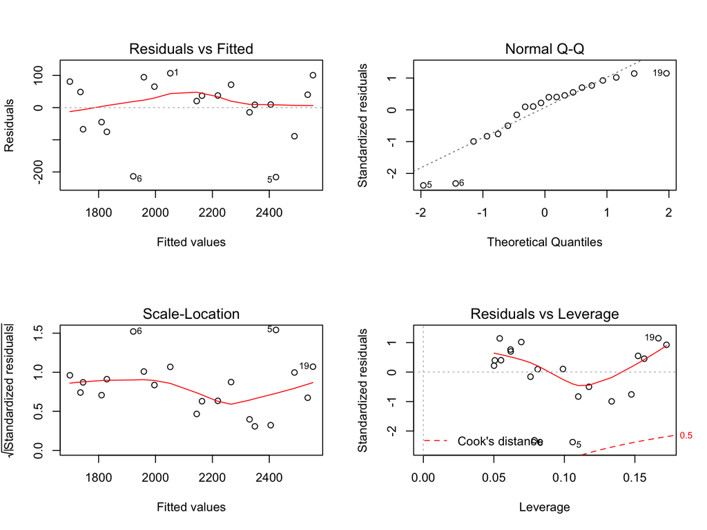

```r
par(mfrow=c(2,2))
plot(lmmotor)
```

# Actividad

Realizar un funcion que tenga utilice el modelo para calcular dado un tiempo de la pieza.

# Qué tan bueno es el modelo

Primero se debe cumplir los supuestos utilizando las gráficas antes mostradas.

Además podemos tener dos criterios adicionales:

- Ajuste del modelo
- Significancia de los parámetros

# Ajuste del modelo

Es necesario determinar una manera de comparar el ajuste del modelo, para esto recordemos el concepto de error definido previamente.

$\epsilon=Y -(\beta_{0}+\beta_{1}X)$

$SCR= \sum_{i=1}^{n}(\epsilon_{i})^{2}= \sum_{i=1}^{n}(Y_{i} -(\beta_{0}+\beta_{1}X_{i}))^{2}$

# Gráficamente el SCR

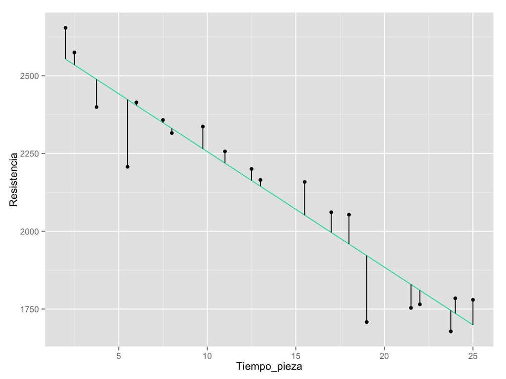

Suma de cuadrados del residuo, si es cero ajuste perfecto, si es “grande” mal ajuste.

# Suma Total cuadrados

Si no existiera el modelo cual es la variabilidad total de Y

$STC= \sum_{i=1}^{n}(Y_{i} -\bar{Y})^{2}$

# Gráficamente el STC

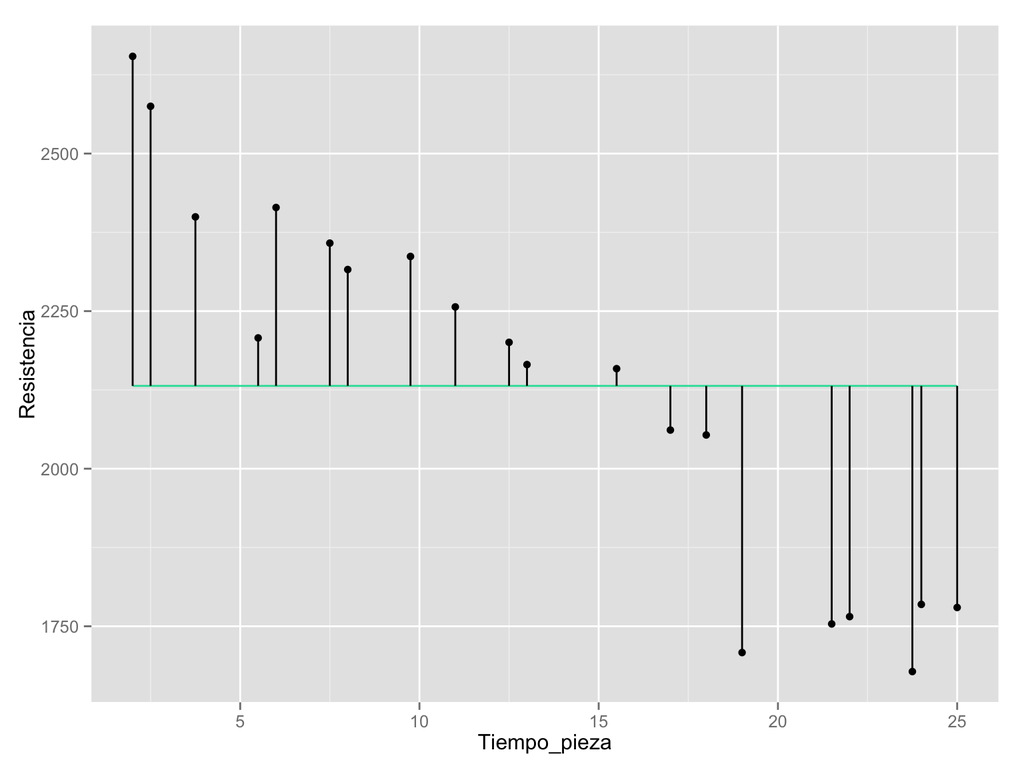

Error de los datos sin modelo

# Coeficiente de determinación

$R^{2}=\frac{STC-SCR}{STC}=1-\frac{SCR}{STC}$

Este índice tiene la ventaja ser acotado, si presenta valor 0 significa que el modelo se tiene poco ajuste, en caso de dar 1 significa que tiene un ajuste perfecto.

# Significancia del modelo

Prueba de Hipótesis de los parámetros:

Prueba para el $\beta_{0}$ $H_{0}: \beta_{0}=0$ $H_{1}: \beta_{0}\neq 0$

Prueba para el $\beta_{1}$

$H_{0}: \beta_{1}=0$ $H_{1}: \beta_{1}\neq 0$

# Prueba de significancia en R

```r
summary(lmmotor)
```

```
##
## Call:
## lm(formula = Resistencia ~ Tiempo_pieza, data = motor)
##
## Residuals:
##     Min      1Q  Median      3Q     Max
## -215.98  -50.68   28.74   66.61  106.76
##
## Coefficients:
##              Estimate Std. Error t value Pr(>|t|)
## (Intercept)  2627.822     44.184   59.48  < 2e-16 ***
## Tiempo_pieza  -37.154      2.889  -12.86 1.64e-10 ***
## ---
## Signif. codes:  0 '***' 0.001 '**' 0.01 '*' 0.05 '.' 0.1 ' ' 1
##
## Residual standard error: 96.11 on 18 degrees of freedom
## Multiple R-squared:  0.9018, Adjusted R-squared:  0.8964
## F-statistic: 165.4 on 1 and 18 DF,  p-value: 1.643e-10
```

# Predicciones del modelo

Una de las utilidades del modelo de regresión es predicir valor que no fueron capturados, por ejemplo saber cual sería la resistencia de las piezas si el tiempo fuera 10 semanas

```r
datosprueba<-data.frame(Tiempo_pieza=c(10))
predict(lmmotor,datosprueba)
```

```
##        1
## 2256.286
```

```r
lmmotor$coefficients%*%c(1,10)
```

```
##          [,1]
## [1,] 2256.286
```

# Predicciones del modelo

la tercera forma es almacenando el valor de los parámetros en variables y utilizarlo de forma directa

```r
B0<-lmmotor$coefficients[1]
B1<-lmmotor$coefficients[2]
B0+B1*10
```

```
## (Intercept)
##    2256.286
```

# Segundo ejemplo regresión lineal

Se tiene datos del peso del cerebro y el peso del cuerpo de 62 pacientes. Se necesita conocer si existe relación entre ambas variables. (ejemplo tomado de http://scg.sdsu.edu/slr-r/)

```r
datoscerebro<-read.csv("datoscerebro.csv",header = T)
str(datoscerebro)
```

```
## 'data.frame':    62 obs. of  3 variables:
##  $ Indice      : int  1 2 3 4 5 6 7 8 9 10 ...
##  $ Peso_cerebro: num  3.38 0.48 1.35 465 36.33 ...
##  $ Peso_cuerpo : num  44.5 15.5 8.1 423 119.5 ...
```

# Gráfico peso cerebro vs peso cuerpo

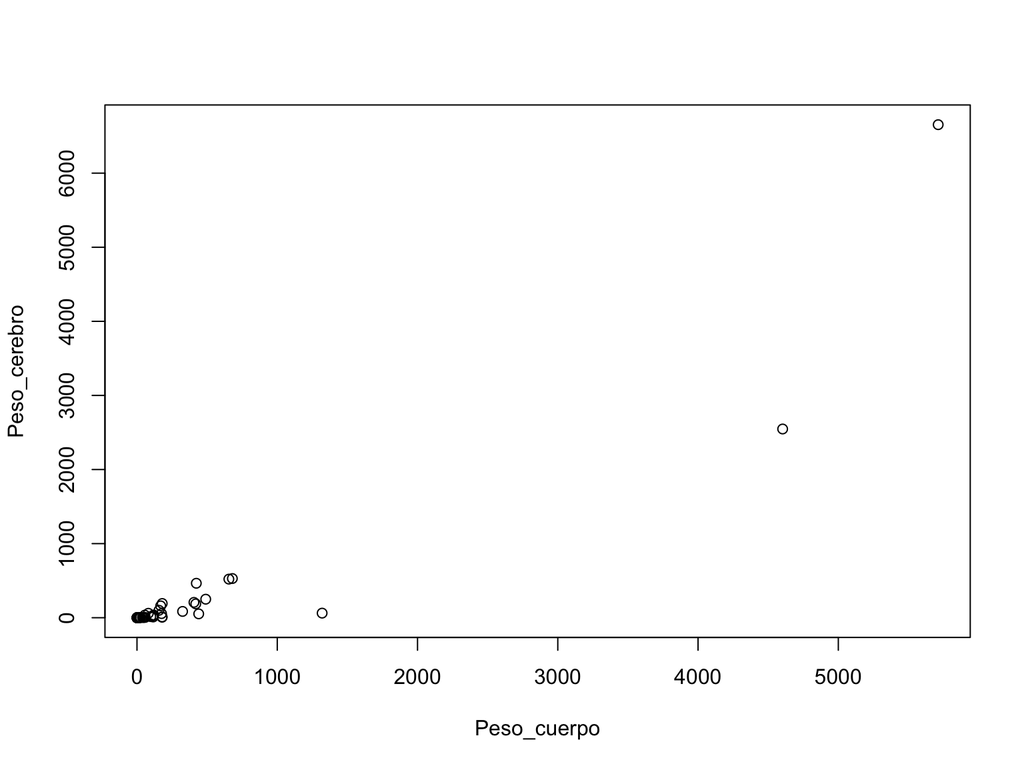

```r
plot(data=datoscerebro,Peso_cerebro~Peso_cuerpo)
```

# Primer modelo planteado

```r
lmcerebro1<-lm(data=datoscerebro,Peso_cerebro~Peso_cuerpo)
lmcerebro1
```

```
##
## Call:
## lm(formula = Peso_cerebro ~ Peso_cuerpo, data = datoscerebro)
##
## Coefficients:
## (Intercept)  Peso_cuerpo
##    -56.8555       0.9029
```

# Hipótesis del modelo

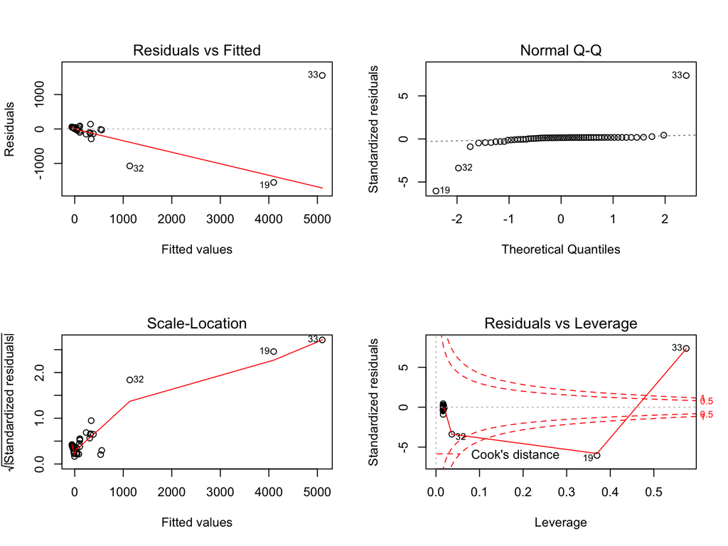

```r
par(mfrow=c(2,2))
plot(lmcerebro1)
```

Se tiene problemas en los datos se puede plantar una transformación.

# Segundo modelo

Modelo con transformación logarítmica

```r
lmcerebro2<-lm(data=datoscerebro,Peso_cerebro~log(Peso_cuerpo))
lmcerebro2
```

```
##
## Call:
## lm(formula = Peso_cerebro ~ log(Peso_cuerpo), data = datoscerebro)
##
## Coefficients:
##      (Intercept)  log(Peso_cuerpo)
##           -307.3             161.2
```

# Supuestos segundo modelo

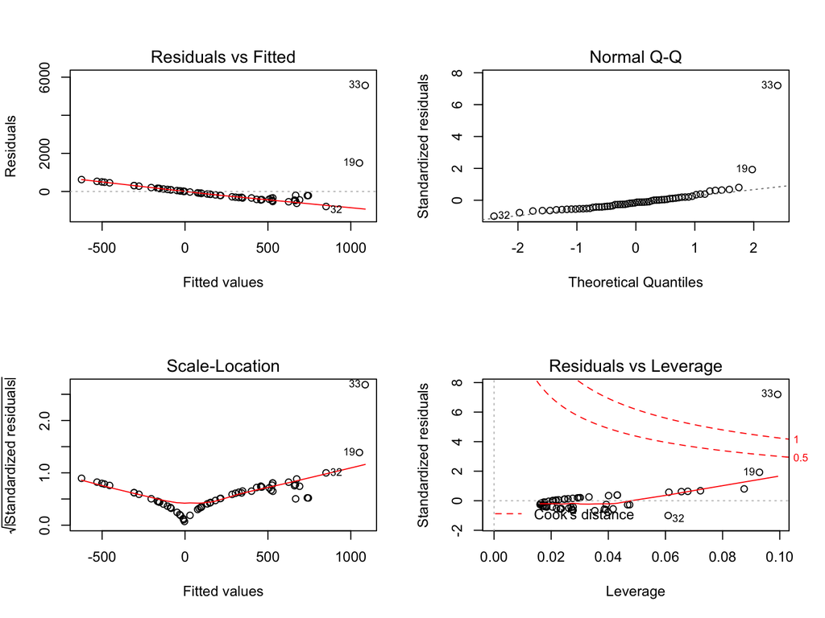

```r
par(mfrow=c(2,2))
plot(lmcerebro2)
```

Se puede plantear una tercer modelo transformando logaritmica de y.

# Formulación tercer modelo

```r
lmcerebro3<-lm(data=datoscerebro,log(Peso_cerebro)~log(Peso_cuerpo))
lmcerebro3
```

```
##
## Call:
## lm(formula = log(Peso_cerebro) ~ log(Peso_cuerpo), data = datoscerebro)
##
## Coefficients:
##      (Intercept)  log(Peso_cuerpo)
##           -2.509             1.225
```

# Supuestos Tercer

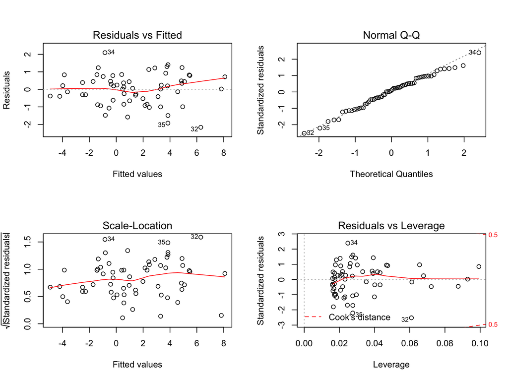

```r
par(mfrow=c(2,2))
plot(lmcerebro3)
```

# Modelo final segundo ejemplo

```r
summary(lmcerebro3)
```

```
##
## Call:
## lm(formula = log(Peso_cerebro) ~ log(Peso_cuerpo), data = datoscerebro)
##
## Residuals:
##      Min       1Q   Median       3Q      Max
## -2.16559 -0.59763  0.09433  0.65789  2.09470
##
## Coefficients:
##                  Estimate Std. Error t value Pr(>|t|)
## (Intercept)      -2.50907    0.18408  -13.63   <2e-16 ***
## log(Peso_cuerpo)  1.22496    0.04638   26.41   <2e-16 ***
## ---
## Signif. codes:  0 '***' 0.001 '**' 0.01 '*' 0.05 '.' 0.1 ' ' 1
##
## Residual standard error: 0.8863 on 60 degrees of freedom
## Multiple R-squared:  0.9208, Adjusted R-squared:  0.9195
## F-statistic: 697.4 on 1 and 60 DF,  p-value: < 2.2e-16
```

# Modelo final

El modelo encontrado fue:

$ln(y)=-2.51+1.225ln(x)+\epsilon$

# Regresión lineal múltiple

Modelos donde intervienen más de una variable independiente se le llaman modelos de regresión lineal múltiple.

$y=\beta_{0}+\beta_{1}x_{1}+\beta_{2}x_{2}+...+\beta_{k}x_{k}+\epsilon$

para el caso de dos regresores el modelo sería:

$y=\beta_{0}+\beta_{1}x_{1}+\beta_{2}x_{2}+\epsilon$

# Ejemplo regresión con dos regresores

Tenemos una empresa de mensajería donde se quiere conocer si la cantidad de cajas y distancia afecta el tiempo de entrega. (ejemplo del libro “Introducción al análisis de regresión lineal, Montgomery et al.”)

```r
datatiempo<-read.csv("datostiempos.csv")
str(datatiempo)
```

```
## 'data.frame':    25 obs. of  4 variables:
##  $ Indice        : int  1 2 3 4 5 6 7 8 9 10 ...
##  $ Tiempo_Entrega: num  16.7 11.5 12 14.9 13.8 ...
##  $ Cantidad      : int  7 3 3 4 6 7 2 7 30 5 ...
##  $ Distancia     : int  560 220 340 80 150 330 110 210 1460 605 ...
```

# gráfico de disperción

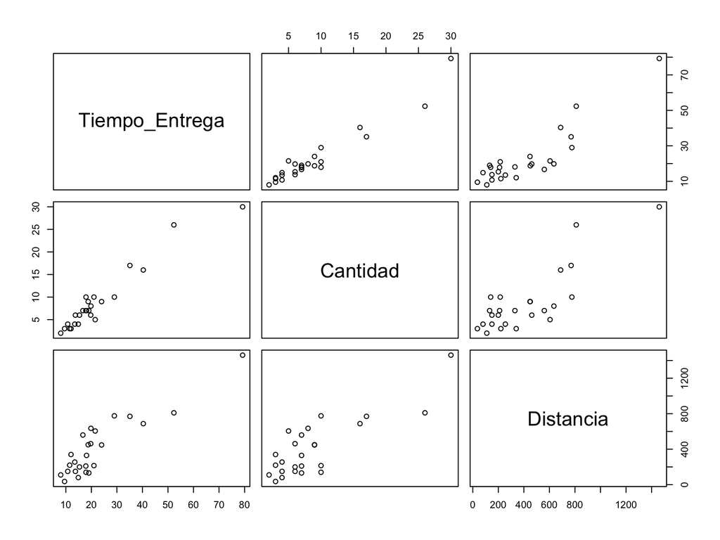

```r
datatiempo2<-datatiempo[,2:4]
plot(datatiempo2)
```

# Regresión lineal ejemplo 3

```r
lmdatatiempo<-lm(data=datatiempo,Tiempo_Entrega~Cantidad+Distancia)
summary(lmdatatiempo)
```

```
##
## Call:
## lm(formula = Tiempo_Entrega ~ Cantidad + Distancia, data = datatiempo)
##
## Residuals:
##     Min      1Q  Median      3Q     Max
## -5.7880 -0.6629  0.4364  1.1566  7.4197
##
## Coefficients:
##             Estimate Std. Error t value Pr(>|t|)
## (Intercept) 2.341231   1.096730   2.135 0.044170 *
## Cantidad    1.615907   0.170735   9.464 3.25e-09 ***
## Distancia   0.014385   0.003613   3.981 0.000631 ***
## ---
## Signif. codes:  0 '***' 0.001 '**' 0.01 '*' 0.05 '.' 0.1 ' ' 1
##
## Residual standard error: 3.259 on 22 degrees of freedom
## Multiple R-squared:  0.9596, Adjusted R-squared:  0.9559
## F-statistic: 261.2 on 2 and 22 DF,  p-value: 4.687e-16
```

# Supuestos

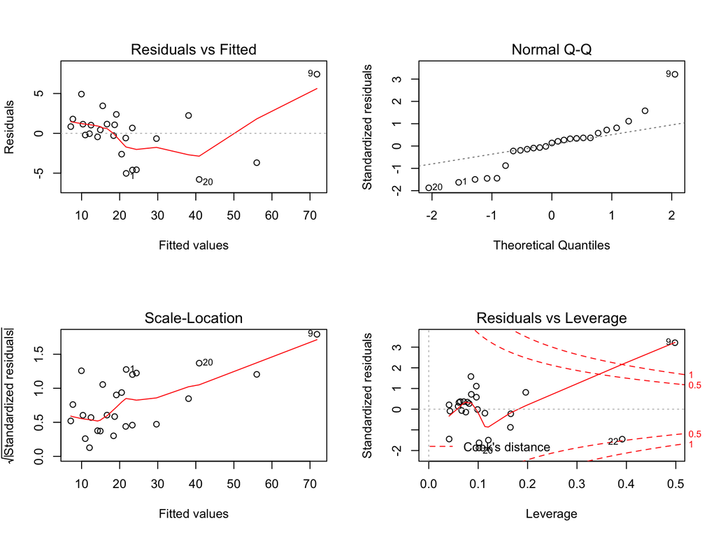

```r
par(mfrow=c(2,2))
plot(lmdatatiempo)
```

# Ejercicio

[, 1] mpg Miles/(US) gallon

[, 2] cyl Number of cylinders

[, 3] disp Displacement (cu.in.)

[, 4] hp Gross horsepower

[, 5] drat Rear axle ratio

[, 6] wt Weight (1000 lbs)

[, 7] qsec 1/4 mile time

[, 8] vs V/S

[, 9] am Transmission (0 = automatic, 1 = manual)

[,10] gear Number of forward gears

[,11] carb Number of carburetors

# Bibliografía

- http://people.duke.edu/~rnau/regintro.htm
- http://scg.sdsu.edu/slr-r/
- http://www.unt.edu/rss/class/mike/5710/Multiple%20Regression.pdf
- http://onlinestatbook.com/2/regression/intro.html
- http://www.virtual.unal.edu.co/cursos/ciencias/2007315/html/un5/cont_04_44.html
- Introducción al análisis de regresión lineal, Montgomery et al.
- https://www.youtube.com/watch?v=iIuMi1HUQFY
- http://freakonometrics.hypotheses.org/tag/gaussian